# **Packages Used**

# **2. Give a real-world scenario from your dataset above to give a practical interpretation of two continuous random variables For each of these continuous variables x: Give their normal distribution plots, and address questions of the form p(x < a), p(a< x< b), p(x > b); were a and b are different observations from your dataset**.

**Air Quality Analysis: Burbank and Chula Vista NO2 AQI**

This analysis compares the NO2 AQI levels in Burbank and Chula Vista, estimating the likelihood of certain AQI values using normal distribution.

### **Steps:**

1. **Assume Normal Distribution**: We assume NO2 AQI follows a normal distribution for both cities.
2. **Calculate Percentiles**: Compute the 25th and 75th percentiles for both cities to identify AQI spread.
3. **Plot Normal Distributions**: Visualize the distribution with areas of interest: below Q1, between Q1 and Q3, and above Q3.
4. **Compute Probabilities**: Use `norm.cdf()` to calculate the probabilities for values less than Q1, between Q1 and Q3, and greater than Q3.

### **Conclusion:**

This analysis provides insights into the likelihood of different NO2 AQI values, helping inform decisions on air quality management for both cities.

```python
from scipy.stats import norm

# Filter data for Burbank and Chula Vista
filtered_data = usap[usap['City'].isin(['Burbank', 'Chula_Vista'])]

# Separate data for each city
burbank_data = filtered_data[filtered_data['City'] == 'Burbank']['NO2_AQI']
chula_vista_data = filtered_data[filtered_data['City'] == 'Chula_Vista']['NO2_AQI']

# mean and standard deviation of city burbank and chula vista.
mean_burbank, std_burbank = burbank_data.mean(), burbank_data.std()
mean_chula_vista, std_chula_vista = chula_vista_data.mean(), chula_vista_data.std()

# Calculate Quartiles (Q1, Q3)
q1_burbank, q3_burbank = np.percentile(burbank_data, [25, 75])
q1_chula_vista, q3_chula_vista = np.percentile(chula_vista_data, [25, 75])

# Generate data for normal distribution plots
x_burbank = np.linspace(mean_burbank - 4*std_burbank, mean_burbank + 4*std_burbank, 500)
y_burbank = norm.pdf(x_burbank, mean_burbank, std_burbank)

x_chula_vista = np.linspace(mean_chula_vista - 4*std_chula_vista, mean_chula_vista + 4*std_chula_vista, 500)
y_chula_vista = norm.pdf(x_chula_vista, mean_chula_vista, std_chula_vista)
```

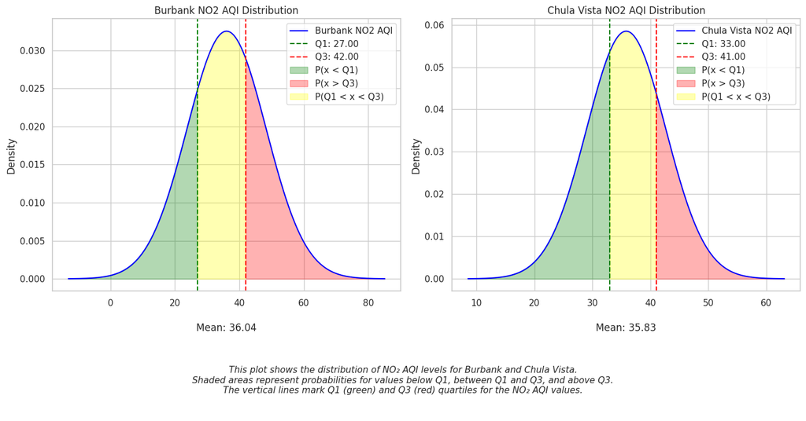

```
Burbank NO2 AQI:
P(x < Q1): 0.2307,
P(Q1 < x < Q3): 0.4559,
P(x > Q3): 0.3135

Chula Vista NO2 AQI:
P(x < Q1): 0.3393,
P(Q1 < x < Q3): 0.4367,
P(x > Q3): 0.2240
```

```python
plt.figure(figsize=(14, 6))

# Burbank NO2_AQI Plot
plt.subplot(1, 2, 1)
plt.plot(x_burbank, y_burbank, label='Burbank NO2 AQI', color='blue')
plt.axvline(q1_burbank, color='green', linestyle='--', label=f'Q1: {q1_burbank:.2f}')
plt.axvline(q3_burbank, color='red', linestyle='--', label=f'Q3: {q3_burbank:.2f}')
plt.fill_between(x_burbank, y_burbank, where=(x_burbank < q1_burbank), color='green', alpha=0.3, label='P(x < Q1)')
plt.fill_between(x_burbank, y_burbank, where=(x_burbank > q3_burbank), color='red', alpha=0.3, label='P(x > Q3)')
plt.fill_between(x_burbank, y_burbank, where=(x_burbank >= q1_burbank) & (x_burbank <= q3_burbank), color='yellow', alpha=0.3, label='P(Q1 < x < Q3)')
plt.title('Burbank NO2 AQI Distribution')
plt.xlabel(f'\nMean: {mean_burbank:.2f}')
plt.ylabel('Density')
plt.legend()

# Chula Vista NO2_AQI Plot
plt.subplot(1, 2, 2)
plt.plot(x_chula_vista, y_chula_vista, label='Chula Vista NO2 AQI', color='blue')
plt.axvline(q1_chula_vista, color='green', linestyle='--', label=f'Q1: {q1_chula_vista:.2f}')
plt.axvline(q3_chula_vista, color='red', linestyle='--', label=f'Q3: {q3_chula_vista:.2f}')
plt.fill_between(x_chula_vista, y_chula_vista, where=(x_chula_vista < q1_chula_vista), color='green', alpha=0.3, label='P(x < Q1)')
plt.fill_between(x_chula_vista, y_chula_vista, where=(x_chula_vista > q3_chula_vista), color='red', alpha=0.3, label='P(x > Q3)')
plt.fill_between(x_chula_vista, y_chula_vista, where=(x_chula_vista >= q1_chula_vista) & (x_chula_vista <= q3_chula_vista), color='yellow', alpha=0.3, label='P(Q1 < x < Q3)')
plt.title('Chula Vista NO2 AQI Distribution')
plt.xlabel(f'\nMean: {mean_chula_vista:.2f}')
plt.ylabel('Density')
plt.legend()

# Add caption below the plot
plt.figtext(0.5, -0.2,
             "This plot shows the distribution of NO₂ AQI levels for Burbank and Chula Vista.\n"
             "Shaded areas represent probabilities for values below Q1, between Q1 and Q3, and above Q3.\n"
             "The vertical lines mark Q1 (green) and Q3 (red) quartiles for the NO₂ AQI values.\n\n",
             ha="center", fontsize=11, style='italic')

plt.tight_layout()
plt.show()

# probabilities for Burbank
prob_burbank_less_q1 = norm.cdf(q1_burbank, mean_burbank, std_burbank)
prob_burbank_q1_to_q3 = norm.cdf(q3_burbank, mean_burbank, std_burbank) - norm.cdf(q1_burbank, mean_burbank, std_burbank)
prob_burbank_more_q3 = 1 - norm.cdf(q3_burbank, mean_burbank, std_burbank)

# probabilities for Chula Vista
prob_chula_vista_less_q1 = norm.cdf(q1_chula_vista, mean_chula_vista, std_chula_vista)
prob_chula_vista_q1_to_q3 = norm.cdf(q3_chula_vista, mean_chula_vista, std_chula_vista) - norm.cdf(q1_chula_vista, mean_chula_vista, std_chula_vista)
prob_chula_vista_more_q3 = 1 - norm.cdf(q3_chula_vista, mean_chula_vista, std_chula_vista)

print(f"Burbank NO2 AQI:")
print(f"P(x < Q1): {prob_burbank_less_q1:.4f}, \nP(Q1 < x < Q3): {prob_burbank_q1_to_q3:.4f}, \nP(x > Q3): {prob_burbank_more_q3:.4f}")

print(f"\nChula Vista NO2 AQI:")
print(f"P(x < Q1): {prob_chula_vista_less_q1:.4f}, \nP(Q1 < x < Q3): {prob_chula_vista_q1_to_q3:.4f}, \nP(x > Q3): {prob_chula_vista_more_q3:.4f}")
```

# **3. Analyze and give a detailed explanation of every step taken to address the questions in 2 above**

1. **Define the Variables:**
   - `NO2 AQI`: Represents the Nitrogen Dioxide air quality index for both Burbank and Chula Vista. It measures the concentration of nitrogen dioxide in the air.
2. **Estimate Distribution Parameters:**
   - `mean_burbank`, `std_burbank`: These are the estimated mean and standard deviation for the NO2 AQI in Burbank, calculated from the dataset.
   - `mean_chula_vista`, `std_chula_vista`: These are the mean and standard deviation for the NO2 AQI in Chula Vista. These values help to understand the central tendency and spread of the data for each city.
3. **Assume Normal Distribution:**
   - The code assumes that the NO2 AQI data follows a normal distribution for both cities. This assumption is often valid for continuous environmental data, as it helps to model the distribution of air quality levels in a standardized way.
4. **Generate x-axis Values:**
   - `x_burbank`, `x_chula_vista`: These lines generate a range of x-axis values to plot the normal distribution curves for NO2 AQI in both Burbank and Chula Vista. The range is typically chosen to cover most of the probability density, extending several standard deviations on either side of the mean.
5. **Calculate Normal Probability Density Function (PDF):**
   - `y_burbank`, `y_chula_vista`: These are the probability density function values for the NO2 AQI data of both cities, calculated using `norm.pdf()` from the `scipy.stats` library. The PDF gives the likelihood of observing specific AQI values within the range.
6. **Calculate Percentiles:**
   - `q1_burbank`, `q3_burbank`, `q1_chula_vista`, `q3_chula_vista`: The 25th and 75th percentiles (Q1 and Q3) are computed for both cities' distributions. These percentiles help to visualize the areas under the curve corresponding to the interquartile range, providing insight into the spread of the data.
7. **Plot Normal Distributions:**
   - `plt.figure()`, `plt.subplot()`, `plt.plot()`: These functions generate plots of the normal distribution for NO2 AQI for both Burbank and Chula Vista. The plots display the distribution of AQI levels in each city.
   - `plt.axvline()`: Vertical lines are drawn to mark the Q1 and Q3 values on the plot. This helps to visualize the spread and central tendency of the AQI data.
   - `plt.fill_between()`: This function fills the area under the curve with different colors to represent different probability regions:
     - Green shading indicates the probability that AQI is less than Q1.
     - Red shading indicates the probability that AQI is greater than Q3.
     - Yellow shading indicates the probability that AQI is between Q1 and Q3.
8. **Calculate Probabilities:**
   - `norm.cdf()`: The cumulative distribution function (CDF) is calculated for each city’s NO2 AQI data. This provides the probability that the AQI value is less than or equal to a specified value. Key probabilities calculated include:
     - Probability that the NO2 AQI is less than Q1.
     - Probability that the NO2 AQI is between Q1 and Q3.
     - Probability that the NO2 AQI is greater than Q3.
9. **Display Results:**
   - The final step is to print the calculated probabilities, providing a clearer understanding of the likelihood of different AQI levels for NO2 in Burbank and Chula Vista. This helps to identify trends in air quality and inform potential interventions for improving air quality in these cities.

# **4. Discuss the appropriateness of using the normal approximation in the chosen scenarios.**

### **Scenario: Burbank and Chula Vista NO2 AQI Analysis**

The code assumes that the NO2 AQI for both Burbank and Chula Vista follows a normal distribution. This assumption is commonly made for environmental data, especially when dealing with continuous variables that are influenced by various factors. However, it's important to consider the following:

1. **Data Distribution:**
   - If the NO2 AQI data for Burbank or Chula Vista are significantly skewed or have outliers, the normal approximation might not be accurate.
   - We should visually inspect the data (e.g., histograms, box plots) for each city to assess the degree of skewness and identify any outliers that could affect the normality assumption.
2. **Sample Size:**
   - The normal approximation tends to be more reliable with larger sample sizes. For smaller datasets, the approximation might not be trustworthy, especially if the data is not normally distributed.
3. **Central Limit Theorem (CLT):**
   - The Central Limit Theorem suggests that as the sample size increases, the distribution of sample means will approach normality, even if the original data is not normally distributed.
   - If the analysis involves sample means or averages, the normal approximation can be reasonable for larger samples, even if the original distribution is not perfectly normal.

### **In the case of Burbank and Chula Vista NO2 AQI:**

- We've made the assumption that the NO2 AQI values in both cities follow a normal distribution.
- It's important to validate this assumption by examining the data through visualizations and statistical tests (e.g., Shapiro-Wilk test).
- If the data distribution is close to normal, then using the normal approximation for calculating probabilities and analyzing the data is appropriate.
- If the distribution significantly deviates from normality, we might need to consider alternative models or transformations to improve the analysis' accuracy.

### **Conclusion:**

- When analyzing real-world data, it's crucial to validate the normality assumption before relying on it for inference or decision-making. Ensuring that the data closely aligns with the normal distribution is key to making robust and accurate statistical conclusions.

# **--Answers to the questions--**

#### **1. Why is data visualization important for understanding a dataset?**

- **Makes it easier to understand:** Data visualization helps break down complicated data so it's easier to see patterns, trends, and outliers.
- **Helps you explore:** It gives a clear way to see how variables are related. For example, scatter plots make it easier to spot correlations.
- **Helps you check the data:** You can easily spot missing data, unusual patterns, or problems in the dataset.
- **Aids in decision-making:** Seeing data in charts or graphs helps analysts decide the best way to analyze or transform the data.

#### **2. Why is data visualization important for communicating key parts of a dataset?**

- **Puts a lot of info in a small space:** Visualization helps show lots of data in a simple way, like using dashboards or summaries.
- **Grabs attention:** A good chart will catch people's attention and make the information more interesting.
- **Shows important findings:** It helps highlight important patterns or issues that might not be obvious just by looking at the numbers.
- **Tells a story:** Good visuals can tell a clear story and make it easier for people to understand the findings without needing a lot of technical knowledge.

#### **3. How does your integrity as an analyst matter when creating a data visualization for others?**

- **Keeps it accurate:** Integrity ensures that the data is shown honestly, without changing scales or leaving out important details to make it look better.
- **Builds trust:** Honest visuals help people trust the data and the person sharing it. Misleading visuals can hurt trust and decision-making.
- **Prevents confusion:** Analysts need to make sure the design is clear and doesn’t mislead people.
- **Stays unbiased:** An analyst should show the data as it is, even if the results aren’t what the audience expects.

#### **4. How many variables do you think you can successfully represent in a visualization? What happens when you exceed this number?**

- **Optimal Number of Variables:**  
  A good visualization can represent **2-4 variables** effectively, depending on the type of chart:
  - **2 Variables:** Line charts, scatter plots.
  - **3 Variables:** Bubble charts, 3D plots, color-coded scatter plots.
  - **4 Variables:** Faceted grids, animated charts, heatmaps with color and size encoding.
- **What Happens When You Exceed This Number?**
  - **Cognitive Overload:** The audience may find it difficult to interpret the chart, leading to confusion or misinterpretation.
  - **Cluttered Design:** Adding too many variables can make the visualization cluttered and unreadable.
  - **Loss of Focus:** Excessive variables dilute the key message of the visualization, making it harder to convey insights effectively.

To address this, analysts should focus on **segmentation**, **interactive visualizations**, or **multiple coordinated views** to break down complex data into digestible components.

# **References to External Sources:**

1. **Websites/Blogs**:
   - [Seaborn Documentation](https://seaborn.pydata.org/): Used for understanding how to use Seaborn to create visualizations like bar and pie charts.
   - [Matplotlib Documentation](https://matplotlib.org/): Consulted for customizing and fine-tuning plots in the project, especially for making clear and informative visualizations.
2. **Datasets**:
   - [US Air Pollution Data - Data Society](https://data.world/data-society/us-air-pollution-data): This dataset was the primary source of data for the analysis of air pollution levels in the United States.
3. **Tutorials/Online Resources**:
   - [Towards Data Science on Medium](https://towardsdatascience.com/): Articles and tutorials on data cleaning, analysis, and visualization helped improve the quality and efficiency of the project’s data processing steps.

# **Code to convert into .html format**

```python
# Converting the file into HTML
from google.colab import files
f = files.upload()

import subprocess
file0 = list(f.keys())[0]
_ = subprocess.run(["pip", "install", "nbconvert"])
_ = subprocess.run(["jupyter", "nbconvert", file0, "--to", "html"])

files.download(file0[:-5]+"html")
```

Upload widget is only available when the cell has been executed in the current browser session. Please rerun this cell to enable.